# NMDS Combined Density

Frank

2022-05-31

# Introduction

These are the codes I used to run an NMDS for the density of benthic macroinvertebrate collected at ten sites in Red Run watershed in four seasons/months in 1987-1988 and 2009. Credit goes to Dr. Jackie Zorz. Check out her work [here.](https://www.researchgate.net/profile/Jackie-Zorz)

## Load the package

Package vegan is the package in R that you can use to run multivariate analyses (Oksanen et al., 2022).

```r
library(vegan)
```

## Load data

Data can be found [here.](https://github.com/tquach123/thesis-codes)

```r
library(readxl)
density_combined <- read_excel("~/thesis-codes/Part a (87-09)/density_combined.xlsx",
     sheet = "Final")
```

## Make a matrix from abundance data

```r
density_wo_su <- density_combined[,4:ncol(density_combined)] #exclude the first column that contains SU information
density_wo_su_rel <- as.matrix(decostand(density_wo_su,method="total")) #calculate relative abundance from abundance data
```

## Run NMDS

```r
set.seed(1)
nmds_density <- metaMDS(density_wo_su_rel,distance="bray",maxit=999,trymax = 500,wascores = T,k=2,autotransform = F) #gotta put autotransform on FALSE so R won't transform your data when you don't want it to.
```

## Plot NMDS graph (standard method)

Don’t go with this method. See below for a much better looking NMDS graph.

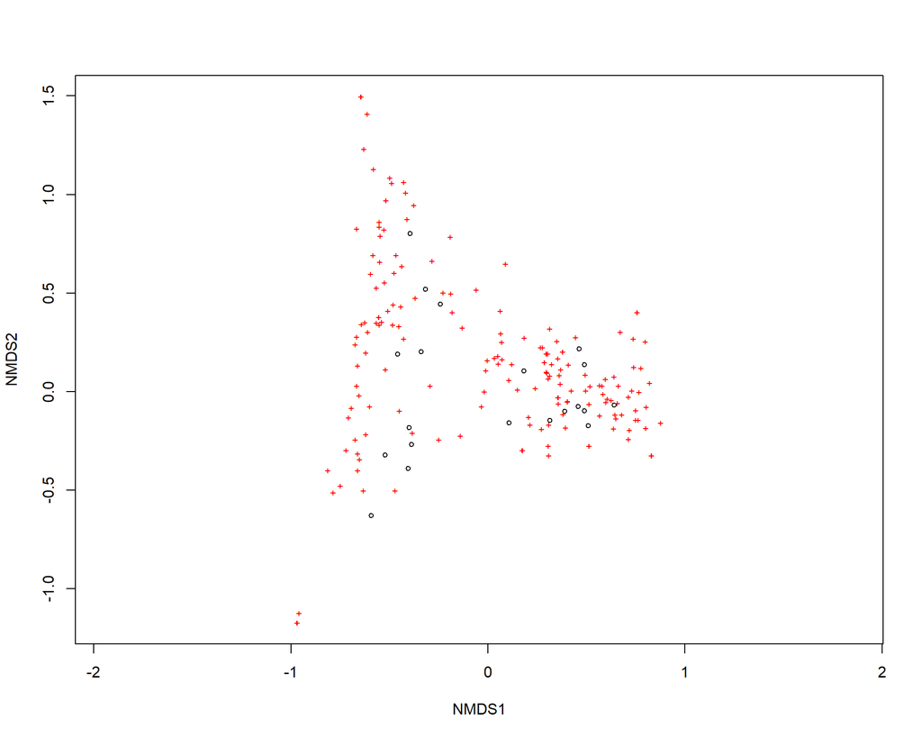

```r
plot(nmds_density)
```

## Add columns of Site, Subwatershed, and Year

This way, I have different Sites, which belong to different sub-watersheds and years. Thus, those sites on the NMDS graph will look distinct, which makes it easier to separate the clusters/groups.

```r
data.scores <- as.data.frame(scores(nmds_density)$sites) #extract NMDS scores
data.scores$Site <- density_combined$Site #add a Site column
data.scores$Year <- density_combined$Year
data.scores$Subwatershed <- density_combined$Subwatershed
head(data.scores) #check the data
```

```
##        NMDS1      NMDS2 Site      Year Subwatershed
## 1 -0.5224205 -0.3213318   B1 1987-1988           B1
## 2 -0.4044312 -0.3901960   B2 1987-1988           B1
## 3 -0.3864518 -0.2687455   B3 1987-1988           B1
## 4 -0.3985387 -0.1832935   B4 1987-1988           B1
## 5 -0.4573394  0.1897331   B5 1987-1988           B1
## 6 -0.3157353  0.5200054   B7 1987-1988           B7
```

## Another way to add columns

Another way to add columns to the existing dataset is to use pipes from the dplyr package (Wickham et al., 2022).

```r
library(dplyr) #load the package
data.scores <- as.data.frame(scores(nmds_density)$sites) #extract NMDS scores
data.scores.dplyr <- data.scores %>% mutate(Site = density_combined$Site,Year=density_combined$Year,
                                            Subwatershed=density_combined$Subwatershed)
library(writexl)
write_xlsx(data.scores.dplyr,"C:/Users/tiena/OneDrive/Documents/thesis-codes/Part a (87-09)/Multiple regression between WC and axis scores/NMDS scores-dplyr.xlsx")
head(data.scores.dplyr)
```

```
##        NMDS1      NMDS2 Site      Year Subwatershed
## 1 -0.5224205 -0.3213318   B1 1987-1988           B1
## 2 -0.4044312 -0.3901960   B2 1987-1988           B1
## 3 -0.3864518 -0.2687455   B3 1987-1988           B1
## 4 -0.3985387 -0.1832935   B4 1987-1988           B1
## 5 -0.4573394  0.1897331   B5 1987-1988           B1
## 6 -0.3157353  0.5200054   B7 1987-1988           B7
```

## Plot the graph using ggplot2

Package ggplot2 is always the way to go when plotting (Wickham, 2016).

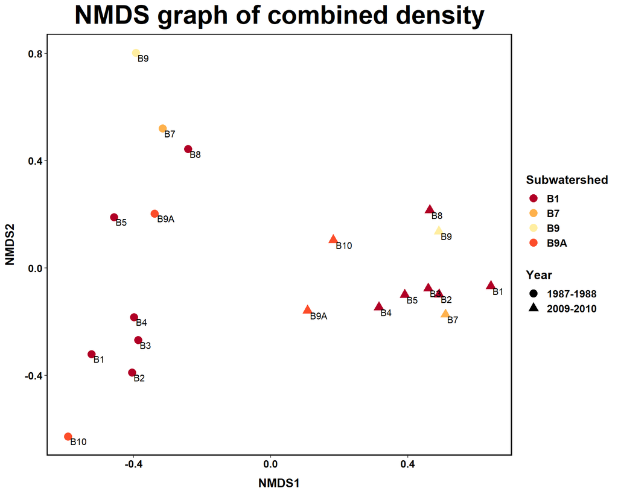

```r
library(ggplot2) #load the package

density_combined_graph <- ggplot(data.scores.dplyr, aes(x = NMDS1, y = NMDS2)) +
    geom_point(size = 4,aes( shape = Year, colour = Subwatershed))+ # geom_polygon(data=data.scores.dplyr,aes(x=NMDS1,y=NMDS2,group=Subwatershed),alpha=0.30); this is to add a little convex polygon to visualize the clusters better. You can try to see how it looks.
    theme(axis.text.y = element_text(colour = "black", size = 12, face = "bold"),
    axis.text.x = element_text(colour = "black", face = "bold", size = 12),
    legend.text = element_text(size = 12, face ="bold", colour ="black"),
    legend.position = "right", axis.title.y = element_text(face = "bold", size = 14),
    axis.title.x = element_text(face = "bold", size = 14, colour = "black"),
    legend.title = element_text(size = 14, colour = "black", face = "bold"),
    panel.background = element_blank(), panel.border = element_rect(colour = "black", fill = NA, size = 1.2),
    legend.key=element_blank(),
    plot.title = element_text(color = "black", size = 30, face = "bold", hjust = 0.5)) +
    labs(
    title = "NMDS graph of combined density") +
    theme(axis.title.x = element_text(margin=margin(t=10)), #add margin to x-axis title
        axis.title.y = element_text(margin=margin(r=10)))+
    labs(x = "NMDS1", colour = "Subwatershed", y = "NMDS2", shape = "Year")  +
    scale_colour_manual(values = c("#b10026", "#feb14c","#ffeea1","#fc4d2a")) +
    geom_text(aes(label=Site),hjust=-0.15, vjust=1.2)

density_combined_graph
```

```r
ggsave("Combined Density NMDS.jpeg",density_combined_graph,width=15,height=8)
```

## Plot a Screeplot

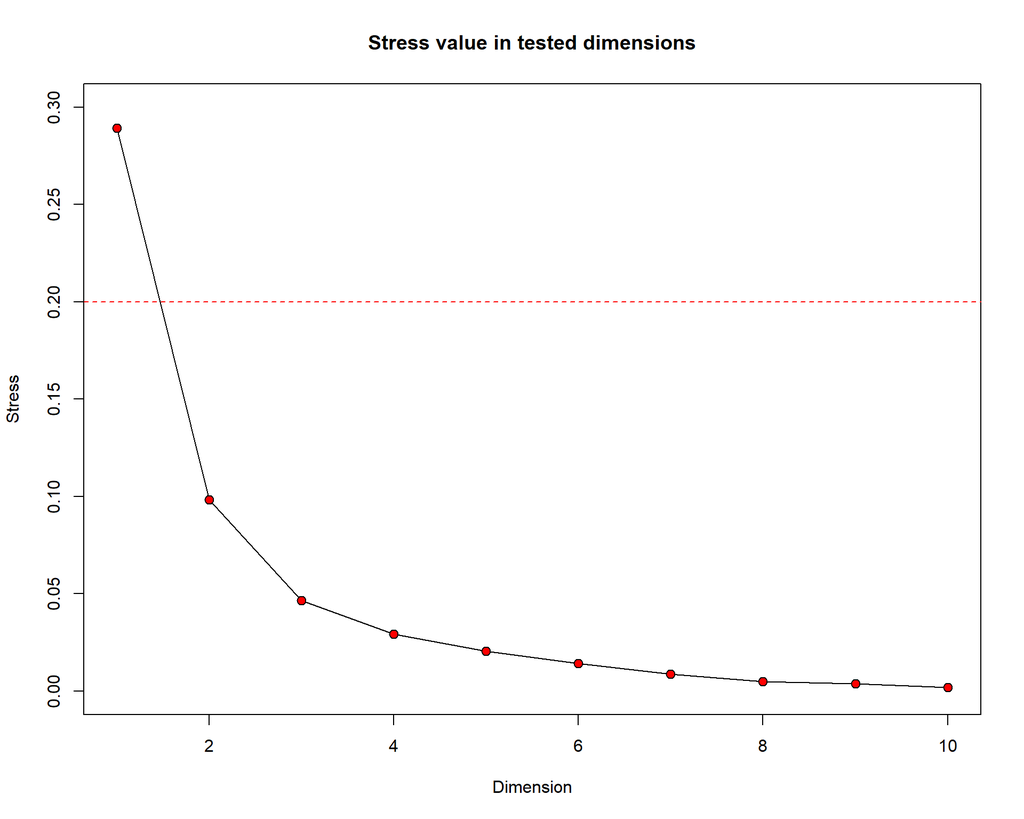

```r
library(goeveg) #load package goeveg

dimcheckMDS(density_wo_su_rel,distance = "bray",k=10,trymax=500,autotransform = F)
```

# References

1. Jari Oksanen, Gavin L. Simpson, F. Guillaume Blanchet, Roeland Kindt, Pierre Legendre, Peter R. Minchin, R.B. O’Hara, Peter Solymos, M. Henry H. Stevens, Eduard Szoecs, Helene Wagner, Matt Barbour, Michael Bedward, Ben Bolker, Daniel Borcard, Gustavo Carvalho, Michael Chirico, Miquel De Caceres, Sebastien Durand, Heloisa Beatriz Antoniazi Evangelista, Rich FitzJohn, Michael Friendly, Brendan Furneaux, Geoffrey Hannigan, Mark O. Hill, Leo Lahti, Dan McGlinn, Marie-Helene Ouellette, Eduardo Ribeiro Cunha, Tyler Smith, Adrian Stier, Cajo J.F. Ter Braak and James Weedon (2022). vegan: Community Ecology Package. R package version 2.6-2. https://CRAN.R-project.org/package=vegan
2. Hadley Wickham, Romain François, Lionel Henry and Kirill Müller (2022). dplyr: A Grammar of Data Manipulation. R package version 1.0.8. https://CRAN.R-project.org/package=dplyr
3. Hadley Wickham. ggplot2: Elegant Graphics for Data Analysis. Springer-Verlag New York, 2016.